# Analysis of Relationship Between CO2 Emissions and Life Expectancy

Author

Claire Savage, Dani Wells, Abby Drongpa

```r
library(tidyverse)
library(here)
library(broom)
library(patchwork)
library(DT)
library(gganimate)
library(gifski)
CO2_emissions <- read_csv(here::here("co2_cons.csv"))
lex_data <- read_csv(here::here("lex.csv"))
```

## Introduction

As the world experiences the increasing effects of climate change, it becomes crucial to understand how different aspects of climate change affect our lives. Since greenhouse gas emissions have increased exponentially post-industrial revolution, it seemed like a good place to start. For this project we looked at the relationship between life expectancy at birth and total CO2 emissions. To do this, we used the “Life expectancy, at birth” and “Consumption CO2 emissions, million tonnes” data sets from Gapminder in our analysis, and both included information on 186 different countries.

Total CO2 emissions (million tonnes) was the explanatory variable. It is total carbon dioxide emitted per capita from each country. We chose CO2 emissions per capita to better account for population size differences between countries. Life expectancy at birth (years) was the response variable. It is the number of years an infant born in a given country in a given year would live if mortality rates stay the same throughout its life. We chose to study the relationship between these variables from 1920 to 2019 because this time period had the most comprehensive data set available. We chose to omit the data post 2019 because we thought the COVID-19 pandemic might have altered the trends visualized in a way which did not reflect the long-term patterns.

We believe that increased levels of CO2 emissions per capita are correlated with a decrease in life expectancy. This is in line with a study conducted by the [National Library of Medicine](https://www.ncbi.nlm.nih.gov/pmc/articles/PMC8782287/#:~:text=Carbon%20emissions%20have%20a%20significantly,decreases%20life%20expectancy%20by%200.012%25.) which found that, “Carbon emissions have a significantly negative impact on life expectancy, suggesting that higher the carbon emissions lower the life expectancy.”

## Methods

In order to analyze the data sets, we started by cleaning them with tidyverse. For the CO2 emissions data set, the negative values in Panama were encoded dashes, so we replaced them with regular dashes in order to convert those numbers to numeric values. The years in question, 1920-2019 were then selected and the table was pivoted into a ‘long’ format where each row had information for a year and country with its respective CO2 emissions value. For the life expectancy data, we first selected the same years as the CO2 emissions (1920-2019), and then took out any NA values. We then pivoted the table so that it was in a similar format to the CO2 emissions, with each year and life expectancy combination in its own row. Once the individual data sets were properly formatted, we combined them by country and year so that for each country-year combo, there was a row with the respective CO2 emissions and life expectancy values.

Once the data sets were cleaned and joined, we were able to conduct our analysis. This included making scatter plots of the raw data, the averaged data, and then running a linear regression to visually explore the relationship between CO2 emissions and life expectancy. We then created a simulated data set to see if our model was a good fit, and then took it a step further by running multiple predictive checks. We used the level of similarity between the observed and simulated data as well as the $R^2$ from the multiple predictive checks to help determine how good of a fit our model was for this scenario.

```r
CO2_emissions_clean <- CO2_emissions %>%
  mutate(across(c(`2003`:`2006`,`2011`:`2013`),
                ~str_replace(.x,
                             pattern = "−",
                             replace = "-")),
         across(c(`2003`:`2006`,`2011`:`2013`), ~
                  as.numeric(.x))) %>%
  select(country, `1920`:`2019`) %>%
  pivot_longer(cols = `1920`:`2019`,
               names_to = "year",
               values_to = "emissions")

lex_clean <- lex_data %>%
  select(country, `1920`:`2019`) %>%
  filter(if_all(c(`1920`:`2019`), ~ !is.na(.))) %>%
  pivot_longer(cols = `1920`:`2019`,
               names_to = "year",
               values_to = "life_exp")

co2life_joined <- inner_join(CO2_emissions_clean, lex_clean)

#Seperating the data into 20 year chunks
years_1920_1939 <- as.character(seq(1920, 1939))
years_1940_1959 <- as.character(seq(1940, 1959))
years_1960_1979 <- as.character(seq(1960, 1979))
years_1980_1999 <- as.character(seq(1980, 1999))
years_2000_2019 <- as.character(seq(2000, 2019))

co2_life_twodecade <- co2life_joined|>
  mutate(
    year = as.factor(year)
  )|>
  mutate(
    twodecade = fct_collapse(year,
                             `1920-1940` = years_1920_1939,
                             `1940-1959` = years_1940_1959,
                             `1960-1979` = years_1960_1979,
                             `1980-1999` = years_1980_1999,
                             `2000-2019` = years_2000_2019
    )

  )


#Averaging the data by country
avg_co2_life_twodecade <- co2_life_twodecade |>
  group_by(country, twodecade) |>
  summarise(
    avg_emissions = mean(emissions, na.rm = TRUE),
    avg_life_exp = mean(life_exp, na.rm = TRUE)
  )
```

## Results

To visualize the relationship between CO2 emissions and life expectancy at birth we used a scatter plot to map the relationship between the variables overtime. For readability we separated the data into five twenty year periods in which we related life expectancy on the y-axis to CO2 emissions on the x-axis. The plot was animated to cycle between the 20 year periods using gganimate.

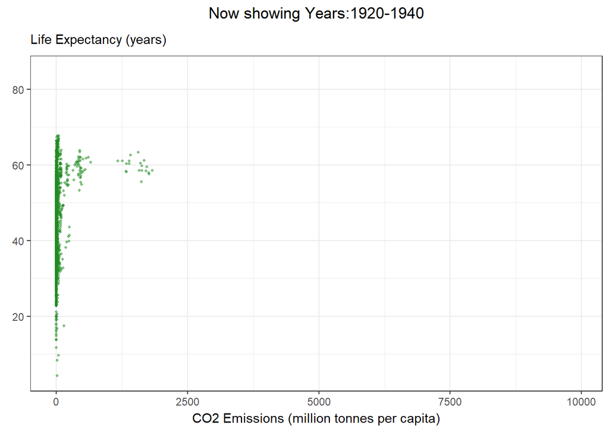

Fig. 1. Animation of the relationship between life expectancy and CO2 emissions as it changed over 20-year intervals between 1920 and 2019.

```r
#The relationship between the two quantitative variables changing over time. Get creative!

animate_plot <- co2_life_twodecade|>
  ggplot(
    aes( x = emissions, y = life_exp)
  ) +
  geom_point(size = 0.8, alpha = 0.5, color = "forestgreen") +
  theme_bw() +
  labs(
    title = "Scatterplot of CO2 emissions Vs. Life Expectancy",
    subtitle = "Life Expectancy (years)",
    y = "",
    x = "CO2 Emissions (million tonnes per capita)"
  ) +
  theme(
    legend.position = "bottom",
    plot.title = element_text(hjust = 0.5)
  ) +
  transition_states(
    twodecade,
    transition_length = 5,
    state_length = 25
  ) +
  ease_aes(y = 'cubic-in-out') +
  enter_fade() +
  exit_fade()+
  ggtitle('Now showing Years:{closest_state}')

animate(animate_plot, renderer = gifski_renderer())
```

```r
#+
#scale_color_viridis_d(
#name = "Period",
#guide = guide_legend(title = "Two-Decade Period")
#)
```

From this graph, we observed that CO2 emissions and life expectancy at birth have increased for most most countries and that life expectancy tended to start plateauing around the 80-85 year range, while CO2 emissions continued to grow exponentially for some countries. We also saw that there is not a strong relationship between life expectancy and CO2 emissions because there was not a strict line that was observed in the scatter plot. While the relationship between these variables was not strong, there seemed to be a weak positive correlation between CO2 emissions and life expectancy, with numerous outliers that seemed to follow the trend of the exponential growth of CO2 emissions.

#### Linear Regression

To get a clearer picture of how life expectancy relates to CO2 emissions across countries, we took the average of both life expectancy and CO2 emissions for all years for each country and created a scatter plot of these values. We also fitted a linear regression line to show the relationship attained when regressing the average life expectancy of each country on it’s average CO2 emissions.

```r
#The relationship between the two quantitative variables you are investigating.
avg_co2_life <- co2life_joined |>
  group_by(country) |>
  summarise(
    avg_emissions = mean(emissions, na.rm = TRUE),
    avg_life_exp = mean(life_exp, na.rm = TRUE)
  )
```

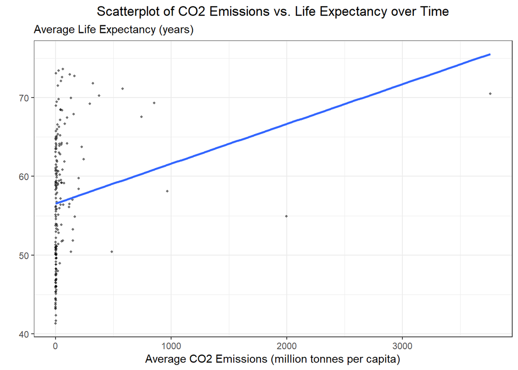

Fig. 2. Relationship between CO2 emissions and life expectancy over time.

```r
avg_co2_life %>%
  ggplot(aes(x = avg_emissions, y = avg_life_exp)) +
  geom_point(size = 0.8, alpha = 0.5) +
  geom_smooth(method = "lm", se = FALSE) +
  theme_bw() +
  labs(
    title = "Scatterplot of CO2 Emissions vs. Life Expectancy over Time",
    subtitle = "Average Life Expectancy (years)",
    x = "Average CO2 Emissions (million tonnes per capita)",
    y = "") +
  theme(
    plot.title = element_text(hjust = 0.5)
    )
```

```r
influential_outliers <- avg_co2_life|>
  filter(avg_emissions > 1000)

datatable(influential_outliers, class = 'cell-border stripe hover order-column',
          options = list(searching = FALSE,
                         lengthMenu = list(c(10, -1), c('10', 'All')),
                         paging = FALSE),
          colnames = c("Country" = "country",
                       "Average Emissions" = "avg_emissions",
                       "Average Life Expectancy" = "avg_life_exp"),
          caption = "Table 1: Influential Outliers"
)
```

|  | Country | Average Emissions | Average Life Expectancy |
| --- | --- | --- | --- |
| 1 | China | 1994.054 | 54.936 |
| 2 | USA | 3760.5 | 70.48 |

```r
mod_co2life <- lm(avg_life_exp ~ avg_emissions, data = avg_co2_life)
tidy_co2life <- tidy(mod_co2life)

tidy_co2life <- tidy_co2life|>
  mutate(
    across(estimate:p.value, ~round(.x, 3))
  )

datatable(tidy_co2life,  class = 'cell-border stripe hover',
          options = list(searching = FALSE,
                         lengthMenu = list(c(10, -1), c('10', 'All')),
                         paging = FALSE),
          colnames = c("Coefficient Estimate" = "estimate",
                       "Standard Error" = "std.error",
                       "T-Statistic" = "statistic",
                       "P-Value" = "p.value"),
          caption = "Table 2: Estimated Coefficients of the Linear Regression",
)
```

|  | term | Coefficient Estimate | Standard Error | T-Statistic | P-Value |
| --- | --- | --- | --- | --- | --- |
| 1 | (Intercept) | 56.57 | 0.61 | 92.812 | 0 |
| 2 | avg_emissions | 0.005 | 0.002 | 2.833 | 0.005 |

#### Model Fit

```r
modfit_table <- augment(mod_co2life) %>%
  summarize(life_re = var(avg_life_exp),
            life_fitt = var(.fitted),
            life_resid = var(.resid)
            )

modfit_table <- modfit_table|>
  mutate(
    across(life_re:life_resid, ~round(.x, 3))
  )

datatable(modfit_table,  class = 'cell-border stripe hover',
          options = list(searching = FALSE,
                         lengthMenu = list(c(10, -1), c('10', 'All')),
                         paging = FALSE),
          colnames = c("Variance in Life Expectancy" = "life_re",
                       "Variance in Fitted Values" = "life_fitt",
                       "Variance in Residuals" = "life_resid"),
          caption = "Table 3: Model Fit Variances",
)
```

|  | Variance in Life Expectancy | Variance in Fitted Values | Variance in Residuals |
| --- | --- | --- | --- |
| 1 | 67.661 | 2.828 | 64.834 |

#### Predictive checks

In order to measure the fit of our model to the data taken from Gapminder, we generated simulated data to compare to our observed results and what the model predicted. If there was a simple linear relationship between average life expectancy and average CO2 emissions, we would assume that within reason, we could generate data that was similar to our observed data by predicting values from the linear regression model and adding in normally distributed errors. Thus, we simulated a random normal distribution of data with the same standard deviation that we observed from our data set and then compared our observed data to our simulated data using two side by side scatter plots.

```r
mod_co2life_predict <- predict(mod_co2life)

mod_co2life_sigma <- sigma(mod_co2life)

noise <- function(x, mean = 0, sd) {
  x + rnorm(length(x),
            mean,
            sd)
}

sim_response <- tibble(sim_life_exp = noise(mod_co2life_predict,
                                            sd = mod_co2life_sigma))

sim_data <- avg_co2_life %>%
  filter(!is.na(avg_life_exp),
         !is.na(avg_emissions)) %>%
  cbind(sim_response)
```

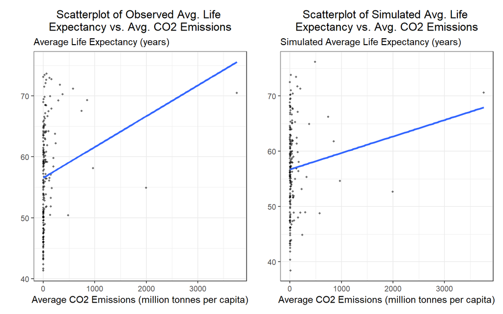

Fig. 3. Comparison of observed vs simulated values for life expectancy depending on CO2 emissions.

```r
obs_reg_avgco2life <- avg_co2_life %>%
  ggplot(aes(x = avg_emissions, y = avg_life_exp)) +
  geom_point(size = 0.8, alpha = 0.5) +
  geom_smooth(method = "lm", se = FALSE) +
  theme_bw() +
  labs(
    title = "Scatterplot of Observed Avg. Life \nExpectancy vs. Avg. CO2 Emissions",
    subtitle = "Average Life Expectancy (years)",
    x = "Average CO2 Emissions (million tonnes per capita)",
    y = "") +
  theme(
    plot.title = element_text(hjust = 0.5)
    )

sim_reg_avgco2life <- sim_data %>%
  ggplot(aes(x = avg_emissions, y = sim_life_exp)) +
  geom_point(size = 0.8, alpha = 0.5) +
  geom_smooth(method = "lm", se = FALSE) +
  theme_bw() +
  labs(
    title = "Scatterplot of Simulated Avg. Life \nExpectancy vs. Avg. CO2 Emissions",
    subtitle = "Simulated Average Life Expectancy (years)",
    x = "Average CO2 Emissions (million tonnes per capita)",
    y = "") +
  theme(
    plot.title = element_text(hjust = 0.5)
  )

obs_reg_avgco2life + sim_reg_avgco2life
```

We created this side-by-side comparison using the patchwork package. From this comparison we noticed a few differences between our observed and simulated data, with the biggest one being the concentration of data points around the y axis. In our observed data, the countries which have approximately 0 carbon emissions have average life expectancies that are fairly evenly distributed between 40 and 70 years of age, whereas in our simulated normally distributed data we see that the simulated data points are clustered around an average life expectancy of 55 years instead of evenly distributed. This would suggest that the actual relationship between CO2 emissions and life expectancy is not well-represented by a simple linear regression model.

#### Multiple Predictive Checks

To further measure the fit of our model we took the observed average life expectancy regressed on 1000 simulations of average life expectancy made by simulating a normal distribution with the same standard error as our observed data. From this we calculated the $R^2$ to measure how much variance in our data set is captured by various simulations. A lower $R^2$ indicates that the model is not a good fit.

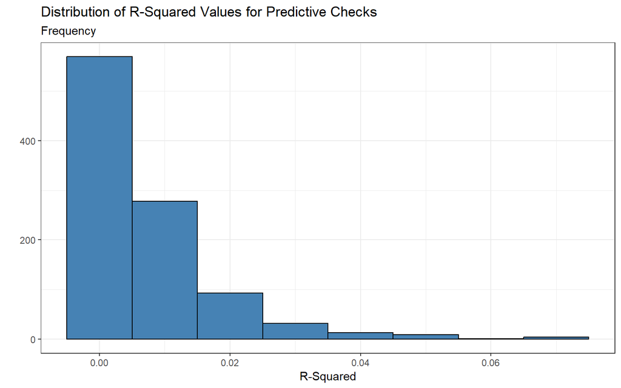

Fig. 4. Histogram of R squared from 1000 regressions of observed average life expectancies on simulated average life expectancies.

```r
simulate_and_regress <- function(mod_co2life_predict, mod_co2life_sigma, avg_co2_life) {

  # Generate sim data
  sim_response_rep <- tibble(sim_life_exp = noise(mod_co2life_predict, sd = mod_co2life_sigma))

  # Combine with observed data
  sim_data_rep <- avg_co2_life %>%
    filter(!is.na(avg_life_exp),
           !is.na(avg_emissions)) %>%
    cbind(sim_response_rep)

  # Perform linear regression and save R-squared
  lm_model <- lm(avg_life_exp ~ sim_life_exp, data = sim_data_rep)
  rsquared <- summary(lm_model)$r.squared

  return(rsquared)
}



# Set seed for reproducibility
set.seed(2003)

r_squared_values <- map_dbl(1:1000, ~simulate_and_regress(mod_co2life_predict, mod_co2life_sigma, avg_co2_life))

r_squared_values %>%
  tibble(rsquared = r_squared_values)%>%
  ggplot(
    aes(x = rsquared)
  ) +
  geom_histogram(binwidth = 0.01, fill = "steelblue", color = "black") +
  labs(title = "Distribution of R-Squared Values for Predictive Checks",
       x = "R-Squared",
       y = "",
       subtitle = "Frequency") +
  theme_bw()
```

$R^2$ values near 1 indicates perfect fit so ideally we would see a distribution with a mean near 1 to indicate that our model is a good fit for the data. However from this histogram we can see that our $R^2$ has a mean close to 0 which indicates that very little of the variability is accounted for. This means that our model is not a good fit for the representing the relationship between CO2 emissions and life expectancy.

## Discussion

From our data set, we found that a linear regression was not a good model to use. Not only did the original data not meet the validity conditions for it, but when the simulated data was created based on the model it showed that the regression model did not accurately predict average life expectancy. Additionally, after running multiple predictive checks and recording the $R^2$, it was seen that a majority of the simulations had an $R^2$ of 0, meaning that 0% of the variability in average life expectancy was explained by the average CO2 emissions per capita.

Since the regression model did not fit the data set, it would be interesting to see what other models might better predict or account for the variance in average life expectancy. It should also be acknowledge though, that there are many different factors that influence the life expectancy of people, and it might be a very complicated model to try to build.

## Conclusion

In conclusion, our study on the relationship between life expectancy at birth and total CO2 emissions across 186 countries from 1920 to 2019 reveals a complex and unexpected dynamic between these variables. Despite predictions that higher CO2 emissions would correlate with lower life expectancies, our findings suggest that there is no direct linear correlation. Our linear regression model indicated a slight increase in life expectancy with rising CO2 emissions, yet the significant variability and the non-linearity of the observed data suggest that CO2 emissions alone are not a definitive factor in determining life expectancy. This study emphasizes the complexity of the factors which affect average life expectancy, and demonstrates the necessity for broader research to fully grasp these relationships.

One of the major confounding variables that likely caused the major discrepancy between our predicted hypothesis and the observed relationship between life expectancy and CO2 emissions is a country’s economic growth. Economic growth is heavily correlated with both life expectancy and CO2 emissions and since we did not include it in our model it introduces a lot of omitted variable bias. The article “[The Relationship between Energy Consumption, CO2 Emissions, Economic Growth, and Health Indicators](https://www.mdpi.com/1660-4601/20/3/2325)” talks about the strong relationship between CO2 emissions and economic growth as well as the relationship between economic growth and life expectancy (Li et al., 2023). From this we can see that the weak positive relationship between CO2 emissions and life expectancy is likely not a direct relationship and is instead a result of omitting GDP from our model. In actuality the relationship we are observing is the one where increases in economic growth and changes in policy increases CO2 emissions and this same economic growth is linked with an increases in positive health outcomes.

## Citations

“CO2 Emissions from Fuel Combustion.” Gapminder, Gapminder Foundation, 2022, http://gapm.io/dco2_consumption_historic.

Li, Jing, et al. “The Relationship between Energy Consumption, CO2 Emissions, Economic Growth, and Health Indicators.” MDPI, Multidisciplinary Digital Publishing Institute, 28 Jan. 2023, www.mdpi.com/1660-4601/20/3/2325.

“Life Expectancy at Birth.” Gapminder, Gapminder Foundation, documentation version 12, https://www.gapminder.org/data/documentation/gd004/.

Müller K (2020). *here: A Simpler Way to Find Your Files*. R package version 1.0.1, https://CRAN.R-project.org/package=here.

Ooms J, Kornel Lesiński, Authors of the dependency Rust crates (2023). *gifski: Highest Quality GIF Encoder*. R package version 1.12.0-2, https://CRAN.R-project.org/package=gifski.

Pedersen T, Robinson D (2024). *gganimate: A Grammar of Animated Graphics*. R package version 1.0.9, https://CRAN.R-project.org/package=gganimate.

Pedersen T (2024). *patchwork: The Composer of Plots*. R package version 1.2.0, https://CRAN.R-project.org/package=patchwork.

Rahman, MM, et al. “Determinants of Life Expectancy in Most Polluted Countries: Exploring the Effect of Environmental Degradation.” PubMed Central, National Library of Medicine, 21 Jan. 2022, www.ncbi.nlm.nih.gov/pmc/articles/PMC8782287/.

Robinson D, Hayes A, Couch S (2023). *broom: Convert Statistical Objects into Tidy Tibbles*. R package version 1.0.5, https://CRAN.R-project.org/package=broom.

Wickham H, Averick M, Bryan J, Chang W, McGowan LD, François R, Grolemund G, Hayes A, Henry L, Hester J, Kuhn M, Pedersen TL, Miller E, Bache SM, Müller K, Ooms J, Robinson D, Seidel DP, Spinu V, Takahashi K, Vaughan D, Wilke C, Woo K, Yutani H (2019). “Welcome to the tidyverse.” *Journal of Open Source Software*, *4*(43), 1686. doi:10.21105/joss.01686 https://doi.org/10.21105/joss.01686.

Xie Y, Cheng J, Tan X (2024). *DT: A Wrapper of the JavaScript Library ‘DataTables’*. R package version 0.32, https://CRAN.R-project.org/package=DT.